Version 1.0.0 - Separate pages

Produced Sunday 22 November 2020

**This is one page of the R Handbook for Epidemiologists, but is being printed as a stand-alone page.**

**You can find the complete handbook on [Github](https://github.com/nsbatra/Epi_R_handbook)**

# R Basics

## Overview

This section is **not** meant as a comprehensive “how to learn R” tutorial. However, it does cover some of the fundamentals that can be good to reference or refresh.

More comprehensive tutorials are available online:  
* Here  
* and Here  
* and even Here  
* Oh yea and Here too (there’s a lot of them)

## Why use R?

## Why use R?

- Reproducibility
- Fewer errors
- Collaboration
- Free

## Installation

## Installation

How to install R

How to install R Studio

Other things you may need to install:  
* TinyTeX  
* Pandoc  
* RTools

## RStudio

## RStudio

### RStudio Orientation

**First, open RStudio.** As their icons can look very similar, be sure you are opening *RStudio* and not R.

For RStudio to function you must also have R installed on the computer (see this section for installation instructions).

**RStudio** is an interface (GUI) for easier use of **R**. You can think of R as being the engine of a vehicle, doing the crucial work, and RStudio as the body of the vehicle (with seats, accessories, etc.) that helps you actually use the engine to move forward!

By default RStudio displays four rectangle panes.

[figure not shown]

*TIP:* If your RStudio displays only one left pane it is because you have no scripts open yet.

**The R Console Pane**

The R Console, by default the left or lower-left pane in R Studio, is the home of the R “engine”. This is where the commands are actually run and non-graphic outputs and error/warning messages appear. You can directly enter and run commands in the R Console, but realize that these commands are not saved as they are when running commands from a script.

If you are familiar with Stata, the R Console is like the Command Window and also the Results Window.

**The Source Pane**  
This pane, by default in the upper-left, is space to edit and run your scripts. This pane can also display datasets (data frames) for viewing.

For Stata users, this pane is similar to your Do-file and Data Editor windows.

**The Environment Pane**  
This pane, by default the upper-right, is most often used to see brief summaries of objects in the R Environment in the current session. These objects could include imported, modified, or created datasets, parameters you have defined (e.g. a specific epi week for the analysis), or vectors or lists you have defined during analysis (e.g. names of regions). Click on the arrow next to a dataframe name to see its variables.

In Stata, this is most similar to Variables Manager window.

**Plots, Packages, and Help Pane**  
The lower-right pane includes several tabs including plots (display of graphics including maps), help, a file library, and available R packages (including installation/update options).

This pane contains the Stata equivalents of the Plots Manager and Project Manager windows.

### RStudio settings

Change RStudio settings and appearance in the Tools drop-down menu, by selecting Global Options

## Scripts

## Scripts

### Why use a script

R scripts (vs. typing in the console)  
* Advantages (reproducability) * General sequence (into, load packages, load data, clean data, conduct analysis, save results) * Commenting

### Rmarkdown

### R notebooks

### RShiny

## Working directory

## Working directory

These tabs cover how to use R working directories, and how this changes when you are working within an R project. **The working directory is the root file location used by R for your work.**  
By default, it will save new files and outputs to this location, and will look for files to import (e.g. datasets) here as well.

```
NOTE: If using an [R project](#rproject), the working directory will default to the R project root folder **IF** you open RStudio by clicking open the R project (the file with .rproj extension))
```

### Set by Command

Use the command `setwd()` with the filepath in quotations, for example: `setwd("C:/Documents/R Files")`

*CAUTION:* If using an RMarkdown script be aware of the following:

In an R Markdown script, the default working directory is the folder the Rmarkdown file (`.Rmd`) is saved to. If you want to change this, you can use `setwd()` as above, but know the change will only apply to that specific code chunk.

To change the working directory for all code chunks in an R markdown, edit the setup chunk to add the `root.dir =` parameter, such as below:

```r
knitr::opts_knit$set(root.dir = 'desired/filepath/here')
```

### Set Manually

Setting your working directory manually (point-and-click)

From RStudio click: Session / Set Working Directory / Choose Directory (you will have to do this each time you open RStudio)

### In an R project

How things change in an R project

## Objects

## Objects

Everything in R is an object. These sections will explain:

- How to create objects (`<-`)
- Types of objects (e.g. data frames, vectors..)
- How to access subparts of objects (e.g. variables in a dataset)
- Classes of objects (e.g. numeric, character, factor)

### Everything is an object

Everything you store in R - datasets, variables, a list of village names, a total population number, even outputs such as graphs - are **objects** which are **assigned a name** and **can be referenced** in later commands.

An object exists when you have assigned it a value (see the assignment section below). When it is assigned a value, the object appears in the Environment (see the upper right pane of RStudio). It can then be operated upon, manipulated, changed, and re-defined.

### Creating objects (`<-`)

**Create objects *by assigning them a value* with the <- operator.**  
You can think of the assignment operator `<-` as the words “is defined as”. Assignment commands generally follow a standard order:

**object_name** <- **value** (or process/calculation that produce a value)

> **EXAMPLE:** You may want to record the current epidemiological reporting week as an object for reference in later code. In this example, the object `reporting_week` is created when it is assigned the character value `"2018-W10"` (the quote marks make these a character value).  
> The object `reporting_week` will then appear in the RStudio Environment pane (upper-right) and can be referenced in later commands.

See the R commands and their output in the boxes below.

```r
reporting_week <- "2018-W10"   # this command creates the object reporting_week by assigning it a value
reporting_week                 # this command prints the current value of reporting_week object in the console
## [1] "2018-W10"
```

*NOTE:* Note the `[1]` in the R console output is simply indicating that you are viewing the first item of the output

*CAUTION:* **An object’s value can be over-written** at any time by running an assignment command to re-define its value. Thus, the **order of the commands run is very important**.

The following command will re-define the value of `reporting_week`:

```r
reporting_week <- "2018-W51"   # assigns a NEW value to the object reporting_week
reporting_week                 # prints the current value of reporting_week in the console
## [1] "2018-W51"
```

**Datasets are also objects and must be assigned names when they are imported.**

In the code below, the object `linelist` is created and assigned the value of a CSV file imported with the **rio** package.

```r
# linelist_raw is created and assigned the value of the imported CSV file
linelist <- rio::import("my_linelist.csv")
```

You can read more about importing and exporting datasets with the section on importing data.

*CAUTION:* A quick note on naming of objects:

- Object names must not contain spaces, but you should use underscore (_) or a period (.) instead of a space.
- Object names are case-sensitive (meaning that Dataset_A is different from dataset_A).
- Object names must begin with a letter (cannot begin with a number like 1, 2 or 3).

### Object Structure

**Objects can be a single piece of data (e.g. `my_number <- 24`), or they can consist of structured data.**

In epidemiology (and particularly field epidemiology), you will *most commonly* encounter data frames and vectors:

| Common structure | Explanation | Example from templates |
| --- | --- | --- |
| Vectors | A container for a sequence of singular objects, all of the same class (e.g. numeric, character). | **“Variables” (columns) in data frames are vectors** (e.g. the variable `age_years`). |
| Data Frames | Vectors (e.g. columns) that are bound together that all have the same number of rows. | `linelist_raw` and `linelist_cleaned` are both data frames. |

Note that to create a vector that “stands alone”, or is not part of a data frame (such as a list of location names), the function `c()` is often used:  
`list_of_names <- c("Ruhengeri", "Gisenyi", "Kigali", "Butare")`

### Variables (`$`)

**Vectors within a data frame (variables in a dataset) can be called, referenced, or created using the `$` symbol.** The `$` symbol connects the name of the column to the name of its data frame. The `$` symbol must be used, otherwise R will not know where to look for or create the column.

```r
# Retrieve the length of the vector age_years
length(linelist$age) # (age is a variable in the linelist data frame)
```

By typing the name of the data frame followed by `$` you will also see a list of all variables in the data frame. You can scroll through them using your arrow key, select one with your Enter key, and avoid spelling mistakes!

[figure not shown]

```r
knitr::include_graphics(here::here("images", "Calling_Names.gif"))
```

*ADVANCED TIP:* Some more complex objects (e.g. an `epicontacts` object may have multiple levels which can be accessed through multiple dollar signs. For example `epicontacts$linelist$date_onset`) .

### Access/View with brackets (`[]`)

You may need to view parts of objects, which is often done using the square brackets `[ ]`.

To view specific rows and columns of a dataset, you can do this using the syntax `dataframe[rows, columns]`:

```r
# View a specific row (2) from dataset, with all columns
linelist[2,]

# View all rows, but just one column
linelist[, "date_onset"]

# View values from row 2 and columns 5 through 10
linelist[2, 5:10]

# View values from row 2 and columns 5 through 10 and 18
linelist[2, c(5:10, 18)]

# View rows 2 through 20, and specific columns
linelist[2:20, c("date_onset", "outcome", "age")]

# View rows and columns based on criteria
# *** Note the dataframe must still be names in the criteria!
linelist[linelist$age > 25 , c("date_onset", "date_birth", "age")]

# Use View() to see the outputs in the RStudio Viewer pane (easier to read)
# *** Note the capital "V" in View() function
View(linelist[2:20, "date_onset"])

# Save as a new object
new_table <- linelist[2:20, c("date_onset")]
```

The square brackets also work to call specific parts of summary() function:

```r
# All of the summary
summary(linelist$age)
##    Min. 1st Qu.  Median    Mean 3rd Qu.    Max.    NA's
##    2.00   47.25   60.00   56.91   72.00   91.00       2

#Just one part
summary(linelist$age)[2]
## 1st Qu.
##   47.25
```

### Object Classes

All the objects stored in R have a *class* which tells R how to handle the object. There are many possible classes, but common ones include:

[output not shown]

**You can test the class of an object by feeding it to the function `class()`**. Note: you can reference a specific column within a dataset using the `$` notation to separate the name of the dataset and the name of the column.

```r
class(linelist$age)     # class should be numeric
## [1] "numeric"

class(linelist$gender)  # class should be character
## [1] "character"
```

**Often, you will need to convert objects or variables to another class.**

| Function | Action |
| --- | --- |
| `as.character()` | Converts to character class |
| `as.numeric()` | Converts to numeric class |
| `as.integer()` | Converts to integer class |
| `as.Date()` | Converts to Date class - Note: see section on dates for details |
| `as.factor()` | Converts to factor - Note: re-defining order of value levels requires extra arguments |

Here is [more online material on classes and data structures in R](https://swcarpentry.github.io/r-novice-inflammation/13-supp-data-structures/).

## Functions

## Functions

This section on functions explains:  
* What a function is and how they work  
* What arguments are  
* What packages are  
* How to get help understanding a function

### Simple Functions

**A function is like a machine that receives inputs, does some action with those inputs, and produces an output.**  
What the output is depends on the function.

**Functions typically operate upon some object placed within the function’s parentheses**. For example, the function `sqrt()` calculates the square root of a number:

```r
sqrt(49)
## [1] 7
```

Functions can also be applied to variables in a dataset. For example, when the function `summary()` is applied to the numeric variable `age` in the dataset `linelist` (what’s the `$` symbol?), the output is a summary of the variable’s numeric and missing values.

```r
summary(linelist$age)
##    Min. 1st Qu.  Median    Mean 3rd Qu.    Max.    NA's
##    2.00   47.25   60.00   56.91   72.00   91.00       2
```

*NOTE:* Behind the scenes, a function represents complex additional code that has been wrapped up for the user into one easy command.

### Functions with Multiple Arguments

Functions often ask for several inputs, called *arguments*, located within the parentheses of the function, usually separated by commas.

- Some arguments are required for the function to work correctly, others are optional.
- Optional arguments have default settings if they are not specified.
- Arguments can take character, numeric, logical (TRUE/FALSE), and other inputs.

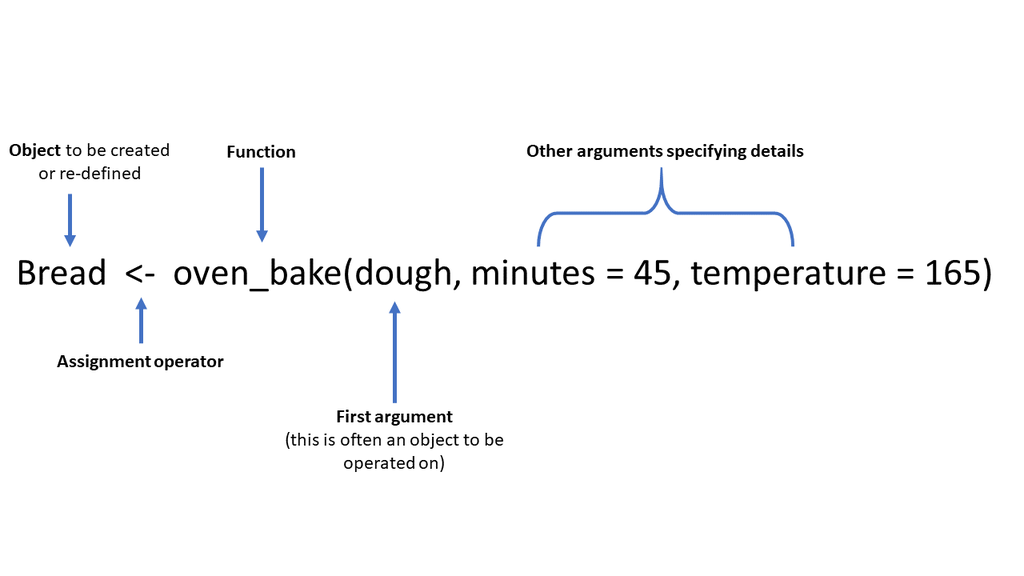

> **For example**, this `age_pyramid()` command produces an age pyramid graphic based on defined age groups and a binary split variable, such as `gender`. The function is given three arguments within the parentheses, separated by commas. The values supplied to the arguments establish `linelist` as the data frame to use, `age_group` as the variable to count, and `gender` as the binary variable to use for splitting the pyramid by color.

*NOTE:* For this example, in the background we have created a new variable called “age_group”. To learn how to create new variable see that section of this handbook

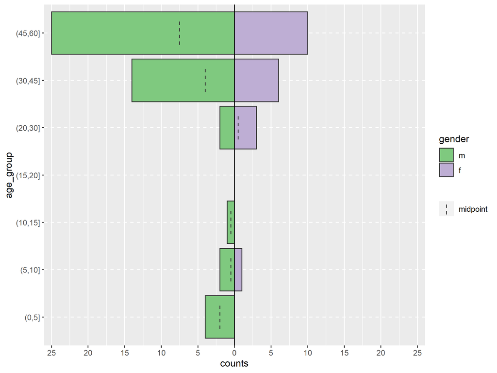

```r
# Creates an age pyramid by specifying the dataframe, age group variable, and a variable to split the pyramid
apyramid::age_pyramid(data = linelist, age_group = "age_group", split_by = "gender")
```

> The first half of an argument assignment (e.g. `data =`) does not need to be specified if the arguments are written in a specific order (specified in the function’s documentation). The below code produces the exact same pyramid as above, because the function expects the argument order: data frame, `age_group` variable, `split_by` variable.

```r
# This command will produce the exact same graphic as above
apyramid::age_pyramid(linelist, "age_group", "gender")
```

**A more complex `age_pyramid()` command might include the *optional* arguments to:**

- Show proportions instead of counts (set `proportional = TRUE` when the default is `FALSE`)
- Specify the two colors to use (`pal =` is short for “palette” and is supplied with a vector of two color names. See the objects page for how the function `c()` makes a vector)

*NOTE:* For arguments specified with an equals symbol (e.g. `coltotals = ...`), their order among the arguments is not important (must still be within the parentheses and separated by commas).

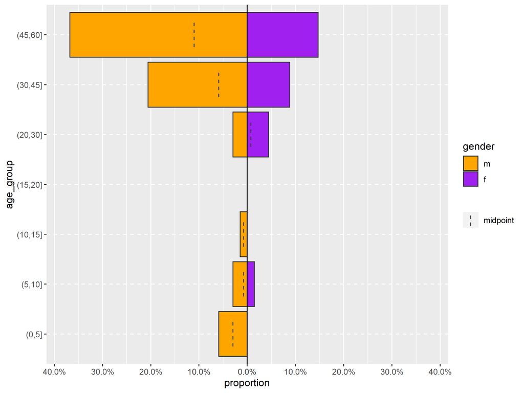

```r
age_pyramid(linelist, "age_group", "gender", proportional = TRUE, pal = c("orange", "purple"))
```

### Packages

**Packages contain functions.**

On installation, R contains “base” functions that perform common elementary tasks. But many R users create specialized functions, which are verified by the R community and which you can download as a **package** for your own use.

One of the more challenging aspects of R is that there are often many functions or packages to choose from to complete a given task.

*Functions* are contained within **packages** which can be downloaded (“installed”) to your computer from the internet. Once a package is downloaded, you access its functions by loading the package with the `library()` command at the beginning of each R session.

```r
# this loads the package "tidyverse" for use in the current R session
library(tidyverse)
```

*NOTE:* While you only have to install a package once, you must load it at the beginning of every R session using `library()` command, or an alternative like **pacman**’s `p_load()` function.

Think of R as your personal library: When you download a package your library gains a book of functions, but each time you want to use a function in that book, you must borrow that book from your library.

For clarity in this handbook, functions are usually preceeded by the name of their package using the `::` symbol in the following way:

`package_name::function_name()`

Once a package is loaded for a session, this explicit style is not necessary. One can just use `function_name()`. However giving the package name is useful when a function name is common and may exist in multiple packages (e.g. `plot()`).  
Using the package name will also load the package if it is not already loaded.

```r
# This command uses the package "rio" and its function "import()" to import a dataset
linelist <- rio::import("linelist.xlsx", which = "Sheet1")
```

**Dependencies**  
Packages often depend on other packages, and these are called “dependencies”. When a package is installed from CRAN, it will typically also install its dependenices.

### Function Help

To read more about a function, you can try searching online for resources OR search in the Help tab of the lower-right RStudio pane.

## Piping

## Piping (`%>%`)

**Two general approaches to R coding are:**

1. **Tidyverse - *piping* an object from function to function**
2. **defining intermediate objects** (and older method, still worth knowing about)

### **Piping**

**Simply explained, the pipe operator (`%>%`) passes an intermediate output from one function to the next.**  
You can think of it as saying “then”. Many functions can be linked together with `%>%`.

- Piping emphasizes a sequence of actions, not the object the actions are being performed on
- Best when a sequence of actions must be performed on one object
- from **magrittr**. Included in **dplyr** and **tidyverse**
- Makes code more clean and easier to read, intuitive
- express a sequence of operations
- the object is altered and then passed on to the next function

Example:

```r
# A fake example of how to bake a care using piping syntax

cake <- flour %>%       # to define cake, start with flour, and then...
  left_join(eggs) %>%   # add eggs
  left_join(oil) %>%    # add oil
  left_join(water) %>%  # add water
  mix_together(utensil = spoon, minutes = 2) %>%                # mix together
  bake(degrees = 350, system = "fahrenheit", minutes = 35) %>%  # bake
  let_cool()            # let it cool down
```

https://cfss.uchicago.edu/notes/pipes/#:~:text=Pipes%20are%20an%20extremely%20useful,code%20and%20combine%20multiple%20operations.

Piping is not a base function. To use piping, the **dplyr** package must be installed and loaded. Near the top of every template script is a code chunk that installs and loads the necessary packages, including **dplyr**. You can [read more about piping in the documentation](https://magrittr.tidyverse.org/).

*CAUTION:* Remember that even when using piping to link functions, if the assignment operator (`<-`) is present, the object to the left will still be over-written (re-defined) by the right side.

### **Intermediate objects**

Better if:  
* You need to manipulate multiple objects  
* There are intermediate steps that are meaningful and deserve separate object names

Risks: creating new objects for each step - lots of objects. If you use the wrong one you might not know. naming can be confusing, errors not easily detectable

either name each intermediate object, or overwrite the original, or combine all the functions together. all come with risks

https://style.tidyverse.org/pipes.html

```r
# a fake example of how to bake a cake using this method (defining intermediate objects)
batter_1 <- left_join(flour, eggs)
batter_2 <- left_join(batter_1, oil)
batter_3 <- left_join(batter_2, water)

batter_4 <- mix_together(object = batter_3, utensil = spoon, minutes = 2)

cake <- bake(batter_4, degrees = 350, system = "fahrenheit", minutes = 35)

cake <- let_cool(cake)
```

Combine all functions together - also difficult to read

```r
# an example of combining/nesting mutliple functions together - difficult to read
cake <- let_cool(bake(mix_together(batter_3, utensil = spoon, minutes = 2), degrees = 350, system = "fahrenheit", minutes = 35))
```

## Key operators and functions

## Key operators and functions

This section details operators in R, such as:  
* Relational operators (less than, equal too..)  
* Logical operators (and, or…)  
* Handling missing values  
* Mathematical operators and functions (+/-, >, sum(), median(), …)  
* The `%in%` operator

### Relational and logical operators

**Relational operators compare values** and are often used when defining new variables and subsets of datasets. Here are the common relational operators in R:

| Function | Operator | Example | Example Result |
| --- | --- | --- | --- |
| Equal to | `==` | `"A" == "a"` | `FALSE` (because R is case sensitive) *Note that == (double equals) is different from = (single equals), which acts like the assignment operator `<-`* |
| Not equal to | `!=` | `2 != 0` | `TRUE` |
| Greater than | `>` | `4 > 2` | `TRUE` |
| Less than | `<` | `4 < 2` | `FALSE` |
| Greater than or equal to | `>=` | `6 >= 4` | `TRUE` |
| Less than or equal to | `<=` | `6 <= 4` | `FALSE` |
| Value is missing | `is.na()` | `is.na(7)` | `FALSE` (see section on missing values) |
| Value is not missing | `!is.na()` | `!is.na(7)` | `TRUE` |

**Logical operators, such as AND and OR, are often used to connect relational operators and create more complicated criteria**. Complex statements might require parentheses ( ) for grouping and order of application.

| Function | Operator |
| --- | --- |
| AND | `&` |
| OR | `\|` (vertical bar) |
| Parentheses | `( )` Used to group criteria together and clarify order |

For example, below, we have a linelist with two variables we want to use to create our case definition, `hep_e_rdt`, a test result and `other_cases_in_hh`, which will tell us if there are other cases in the household. The command below uses the function `case_when()` to create the new variable `case_def` such that:

```r
linelist_cleaned <- linelist_cleaned %>%
  mutate(case_def = case_when(
    is.na(hep_e_rdt) & is.na(other_cases_in_hh)           ~ NA_character_,
    hep_e_rdt == "Positive"                               ~ "Confirmed",
    hep_e_rdt != "Positive" & other_cases_in_hh == "Yes"  ~ "Probable",
    TRUE                                                  ~ "Suspected"
  ))
```

| Criteria in example above | Resulting value in new variable “case_def” |
| --- | --- |
| If the value for variables `hep_e_rdt` and `other_cases_in_hh` are missing | `NA` (missing) |
| If the value in `hep_e_rdt` is “Positive” | “Confirmed” |
| If the value in `hep_e_rdt` is NOT “Positive” AND the value in `other_cases_in_hh` is “Yes” | “Probable” |
| If one of the above criteria are not met | “Suspected” |

### Missing Values

**In R, missing values are represented by the special value `NA`** (capital letters N and A - not in quotation marks). If you import data that records missing data in another way (e.g. 99, “Missing”, or .), you may want to re-code those values to `NA`.

**To test whether a value is `NA`, use the special function `is.na()`**, which returns `TRUE` or `FALSE`.

```r
rdt_result <- c("Positive", "Suspected", "Positive", NA)   # two positive cases, one suspected, and one unknown
is.na(rdt_result)  # Tests whether the value of rdt_result is NA
## [1] FALSE FALSE FALSE  TRUE
```

### Mathematics and statistics

All the operators and functions in this page is automatically available using **base** R.

#### Mathematical operators

These are often used to perform addition, division, to create new columns, etc. Below are common mathematical operators in R. Whether you put spaces around the operators is not important.

| Objective | Example in R |
| --- | --- |
| addition | 2 + 3 |
| subtraction | 2 - 3 |
| multiplication | 2 * 3 |
| division | 30 / 5 |
| exponent | 2^3 |
| order of operations | ( ) |

#### Mathematical functions

[output not shown]

#### Statistical functions:

*CAUTION:* The functions below will by default include missing values in calculations. Missing values will result in an output of NA, unless the argument `na.rm=TRUE` is specified

| Objective | Function |
| --- | --- |
| mean (average) | mean(x, na.rm=T) |
| median | median(x, na.rm=T) |
| standard deviation | sd(x, na.rm=T) |
| quantiles* | quantile(x, probs) |
| sum | sum(x, na.rm=T) |
| minimum value | min(x, na.rm=T) |
| maximum value | max(x, na.rm=T) |
| range of numeric values | range(x, na.rm=T) |
| summmary** | summary(x) |

*`quantile()`: x is the numeric vector to examine, and probs is a numeric vector with probabilities within 0 and 1.0, e.g `c(0.5, 0.8, 0.85)`

**`summary()`: gives a summary on a numeric vector including mean, median, and common percentiles

#### Other useful functions:

| Objective | Function | Example |
| --- | --- | --- |
| create a sequence | seq(from, to, by) | `seq(1, 10, 2)` |
| repeat x, n times | rep(x, ntimes) | `rep(1:3, 2)` or `rep(c("a", "b", "c"), 3)` |
| subdivide a numeric vector | cut(x, n) | `cut(linelist$age, 5)` |

### `%in%`

## Loading Packages

## Loading Packages

This section describes the several ways to install a package:  
* Via the online package repository (CRAN)  
* From a ZIP file  
* From Github

### CRAN

### ZIP files

### Github

## Errors & Warnings

## Errors & Warnings

This section explains:  
* General syntax for writing R code  
* Code assists  
* the difference between errors and warnings

### General Syntax

A few things to remember when writing commands in R, to avoid errors and warnings:

- Always close parentheses - tip: count the number of opening “(” and closing parentheses “)” for each code chunk
- Avoid spaces in column and object names. Use underscore ( _ ) or periods ( . ) instead
- Keep track of and remember to separate a function’s arguments with commas
- R is case-sensitive, meaning `Variable_A` is *different* from `variable_A`

### Code assists

Any script (RMarkdown or otherwise) will give clues when you have made a mistake. For example, if you forgot to write a comma where it is needed, or to close a parentheses, RStudio will raise a flag on that line, on the right side of the script, to warn you.

### Errors and Warnings

When a command is run, the R Console may show you warning or error messages in red text.

- A **warning** means that R has completed your command, but had to take additional steps or produced unusual output that you should be aware of.
- An **error** means that R was not able to complete your command.

Look for clues:

- The error/warning message will often include a line number for the problem.
- If an object “is unknown” or “not found”, perhaps you spelled it incorrectly, forgot to call a package with library(), or forgot to re-run your script after making changes.

If all else fails, copy the error message into Google along with some key terms - chances are that someone else has worked through this already!

## Recommended training

## Recommended training

### Cheatsheets

### Courses